# Introduction to R - Part 7

Katarzyna Kedzierska

2 October 2019

```r
needed_packages <- c("tidyverse", "ggsci")
for (pkg in needed_packages) {
  if (!require(pkg, quietly = TRUE, character.only = TRUE)) {
    print(paste0("WARNING! Installing ", pkg))
    install.packages(pkg)
  }
  library(pkg, character.only = TRUE)
}
```

# More tidyverse

```r
library(tidyverse)
data(starwars)
starwars %>%
  head()
```

| name | height | mass | hair_color | skin_color | eye_color | birth_year | gender | homeworld | species | films | vehicles | starships |
| --- | --- | --- | --- | --- | --- | --- | --- | --- | --- | --- | --- | --- |
| Luke Skywalker | 172 | 77 | blond | fair | blue | 19.0 | male | Tatooine | Human |  |  |  |
| C-3PO | 167 | 75 | NA | gold | yellow | 112.0 | NA | Tatooine | Droid |  |  |  |
| R2-D2 | 96 | 32 | NA | white, blue | red | 33.0 | NA | Naboo | Droid |  |  |  |
| Darth Vader | 202 | 136 | none | white | yellow | 41.9 | male | Tatooine | Human |  |  |  |
| Leia Organa | 150 | 49 | brown | light | brown | 19.0 | female | Alderaan | Human |  |  |  |
| Owen Lars | 178 | 120 | brown, grey | light | blue | 52.0 | male | Tatooine | Human |  |  |  |

# Revision

## summarise

```r
starwars %>%
  summarise(median_height = median(height),
            median_mass = median(mass))
```

| median_height | median_mass |
| --- | --- |
| NA | NA |

```r
starwars %>%
  summarise(median_height = median(height, na.rm = TRUE),
            median_mass = median(mass, na.rm = TRUE))
```

| median_height | median_mass |
| --- | --- |
| 180 | 79 |

## group_by

```r
starwars %>%
  group_by(gender) %>%
  summarise(median_height = median(height, na.rm = TRUE),
            median_mass = median(mass, na.rm = TRUE))
```

| gender | median_height | median_mass |
| --- | --- | --- |
| NA | 97 | 32.0 |
| female | 166 | 52.5 |
| hermaphrodite | 175 | 1358.0 |
| male | 183 | 80.0 |
| none | 200 | 140.0 |

## mutate

```r
starwars %>%
  mutate(height_in = height / 2.54) %>%
  select(name, height, height_in) %>%
  head()
```

| name | height | height_in |
| --- | --- | --- |
| Luke Skywalker | 172 | 67.71654 |
| C-3PO | 167 | 65.74803 |
| R2-D2 | 96 | 37.79528 |
| Darth Vader | 202 | 79.52756 |
| Leia Organa | 150 | 59.05512 |
| Owen Lars | 178 | 70.07874 |

## filter

```r
starwars %>%
  group_by(gender) %>%
  filter(!is.na(gender), !is.na(height), !is.na(mass)) %>%
  summarise(median_height = median(height),
            median_mass = median(mass))
```

| gender | median_height | median_mass |
| --- | --- | --- |
| female | 169 | 52.5 |
| hermaphrodite | 175 | 1358.0 |
| male | 183 | 80.0 |
| none | 200 | 140.0 |

## top_n

```r
starwars %>%
  group_by(gender) %>%
  top_n(1, height)
```

| name | height | mass | hair_color | skin_color | eye_color | birth_year | gender | homeworld | species | films | vehicles | starships |
| --- | --- | --- | --- | --- | --- | --- | --- | --- | --- | --- | --- | --- |
| C-3PO | 167 | 75 | NA | gold | yellow | 112 | NA | Tatooine | Droid |  |  |  |
| Jabba Desilijic Tiure | 175 | 1358 | NA | green-tan, brown | orange | 600 | hermaphrodite | Nal Hutta | Hutt |  |  |  |
| IG-88 | 200 | 140 | none | metal | red | 15 | none | NA | Droid |  |  |  |
| Yarael Poof | 264 | NA | none | white | yellow | NA | male | Quermia | Quermian |  |  |  |
| Taun We | 213 | NA | none | grey | black | NA | female | Kamino | Kaminoan |  |  |  |

## gather

```r
starwars %>%
  select(name, height, mass) %>%
  arrange(name) %>%
  head()
```

| name | height | mass |
| --- | --- | --- |
| Ackbar | 180 | 83 |
| Adi Gallia | 184 | 50 |
| Anakin Skywalker | 188 | 84 |
| Arvel Crynyd | NA | NA |
| Ayla Secura | 178 | 55 |
| Bail Prestor Organa | 191 | NA |

```r
starwars %>%
  select(name, height, mass) %>%
  gather(key = variable,
         value = value,
         height, mass) %>%
  arrange(name) %>%
  head()
```

| name | variable | value |
| --- | --- | --- |
| Ackbar | height | 180 |
| Ackbar | mass | 83 |
| Adi Gallia | height | 184 |
| Adi Gallia | mass | 50 |
| Anakin Skywalker | height | 188 |
| Anakin Skywalker | mass | 84 |

## spread

```r
starwars %>%
  select(name, height, mass) %>%
  gather(key = variable,
         value = value,
         height, mass) %>%
  arrange(name) %>%
  head()
```

| name | variable | value |
| --- | --- | --- |
| Ackbar | height | 180 |
| Ackbar | mass | 83 |
| Adi Gallia | height | 184 |
| Adi Gallia | mass | 50 |
| Anakin Skywalker | height | 188 |
| Anakin Skywalker | mass | 84 |

```r
starwars %>%
  select(name, height, mass) %>%
  gather(key = variable,
         value = value,
         height, mass) %>%
  spread(variable, value) %>%
  arrange(name) %>%
  head()
```

| name | height | mass |
| --- | --- | --- |
| Ackbar | 180 | 83 |
| Adi Gallia | 184 | 50 |
| Anakin Skywalker | 188 | 84 |
| Arvel Crynyd | NA | NA |
| Ayla Secura | 178 | 55 |
| Bail Prestor Organa | 191 | NA |

## join

```r
tmp_df
```

| gender | genedr_modified |
| --- | --- |
| female | Female |
| hermaphrodite | Hermaphrodite |
| none | None |
| NA | No information |

```r
starwars %>%
  select(name, gender) %>%
  right_join(tmp_df) %>%
  arrange(name) %>%
  head()
```

| name | gender | genedr_modified |
| --- | --- | --- |
| Adi Gallia | female | Female |
| Ayla Secura | female | Female |
| Barriss Offee | female | Female |
| BB8 | none | None |
| Beru Whitesun lars | female | Female |
| C-3PO | NA | No information |

```r
starwars %>%
  select(name, gender) %>%
  full_join(tmp_df) %>%
  arrange(name) %>%
  head()
```

[output not shown]

# Excercises

1. Which specie is the heaviest?
2. Who’s the tallest?
3. Who is the thinnest? (lowest mass to height ratio)
4. Who is an outlier on the height to mass ratio plot below.
5. Who has appeared in all movies? Who has appeared in the least movies?
6. List the most represented species from each homeworld.

[output not shown]

1. Which specie is the heaviest?

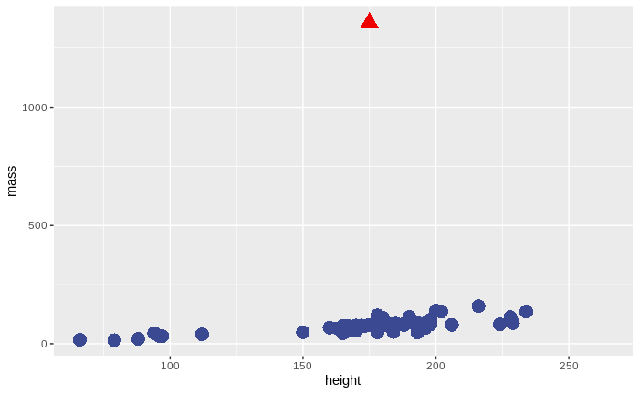

```r
starwars %>%
  mutate(out = mass>1000) %>%
  replace_na(list(out = FALSE)) %>%
  ggplot(., aes(height, mass, color = out, shape = out)) +
  geom_point(size = 5) +
  scale_color_aaas() +
  theme(legend.position = "none")
```

2. Who’s the tallest?

[output not shown]

3. Who is the thinnest? (lowest mass to height ratio)

Column `starships` stores information of starships given charater piloted. It stores the names of those starships as a `vector`. Firstly, create a new column `n_starships` which stores number of ships each character piloted. Secondly, list all the characters that piloted the same starship together with that starship name.

```r
# your code here
```

Do the same for the `vehicles` column.

Now, lets switch datasets. The following excercises and data description below are taken from [R for Data Science by Hadley Wickham](https://r4ds.had.co.nz). Deffo check it out!

The dataset comes from `nycflights13` package, the `flights` data frame contains all 336,776 flights that departed from New York City in 2013. The data comes from the US Bureau of Transportation Statistics, and is documented in `?flights`

```r
if (!require("nycflights13", character.only = TRUE,
             warn.conflicts = FALSE, quietly = TRUE)) {
  print("Installing nycflights13 package.")
  install.packages("nycflights13")
}

library(nycflights13)
flights
```

[output not shown]

Find all flights that  
* Had an arrival delay of two or more hours  
* Flew to Houston (IAH or HOU)  
* Were operated by United, American, or Delta  
* Departed in summer (July, August, and September)  
* Arrived more than two hours late, but didn’t leave late  
* Were delayed by at least an hour, but made up over 30 minutes in flight  
* Departed between midnight and 6am (inclusive)

```r
# your code goes here
```

Another useful dplyr filtering helper is `between()`. What does it do? Can you use it to simplify the code needed to answer the previous challenges?

```r
# your code goes here
```

How many flights have a missing dep_time? What other variables are missing? What might these rows represent?

```r
# your code goes here
```

Which flights travelled the longest? Which travelled the shortest?

```r
# your code goes here
```

What does the one_of() function do? Why might it be helpful in conjunction with this vector?

```r
vars <- c("year", "month", "day", "dep_delay", "arr_delay")
# your code goes here
```

Find the 10 most delayed flights using a ranking function. How do you want to handle ties? Carefully read the documentation for `min_rank()`.

```r
# your code goes here
```

Which carrier has the worst delays? Challenge: can you disentangle the effects of bad airports vs. bad carriers? Why/why not? (Hint: think about `flights %>% group_by(carrier, dest) %>% summarise(n())`)

```r
# your code goes here
```